# data_cleaning

```python
# import necessary libraries
import numpy as np
import pandas as pd
import seaborn as sns
import matplotlib.pyplot as plt
import matplotlib.colors as mcolors
from sklearn.pipeline import Pipeline
from sklearn.preprocessing import FunctionTransformer, OneHotEncoder, LabelEncoder
from sklearn.linear_model import LinearRegression, LogisticRegression
from sklearn.base import BaseEstimator, TransformerMixin
from sklearn.utils.validation import check_is_fitted
from IPython.display import Markdown


# load data
df = pd.read_csv('/Users/morgannix/Data_Science/JupyterLab/Portfolio/dirty_calories.csv')
# we know that User_ID is a unique identifier and non-informative
df = df.set_index('User_ID')

tick = "✓"
```

## Data Cleaning

This report outlines the data cleaning steps applied to the dataset in preparation for downstream analysis and modeling. The cleaning process focuses on identifying and resolving issues such as inconsistent data types and missing or malformed entries. These steps are essential to ensure data quality and integrity, and to prepare the dataset for reliable modeling and interpretation.

**Dataset Overview:**

- Number of observations: 15,000
- Target variable: `Calories`

### Data types and missing values

```python
# create dataframe of summary information
summary_df = pd.DataFrame({
    'Column': df.columns,
    'Data Type': df.dtypes.values,
    'Non-Null Count': df.notnull().sum().values,
    'Null Count': df.isnull().sum().values,
})

summary_df['Null %'] = (summary_df['Null Count'] / len(df) * 100)
summary_df = summary_df.sort_values('Null %', ascending=False).reset_index(drop=True)
summary_df = summary_df.style.hide(axis='index'
    ).set_properties(subset=['Column'], **{'text-align': 'left'}
    ).set_table_styles([{'selector': 'th.col0', 'props': [('text-align', 'left')]}]
    ).format({'Null %': '{:.2f}'})

display(summary_df)
```

| Column | Data Type | Non-Null Count | Null Count | Null % |
| --- | --- | --- | --- | --- |
| Gender | object | 14253 | 747 | 4.98 |
| Age | float64 | 14369 | 631 | 4.21 |
| Duration | object | 14441 | 559 | 3.73 |
| Heart_Rate | float64 | 14501 | 499 | 3.33 |
| Weight | float64 | 14865 | 135 | 0.90 |
| Height | float64 | 14878 | 122 | 0.81 |
| Body_Temp | float64 | 14903 | 97 | 0.65 |
| Calories | float64 | 15000 | 0 | 0.00 |

Note: In Pandas, dtype `object` indicates values are either Python type `str` or of mixed type, while `float64` indicates numerical values (Python `float`).

### Categorical Features

Columns `Gender` and `Duration` are of data type object. These should be investigated for type inconsistencies and malformed values.

```python
# Get the type and count of each non-null value
type_summary = []

for col in ['Gender', 'Duration']:
    types = df[col].dropna().map(type).value_counts()
    for t, count in types.items():
        type_summary.append({'Feature': col, 'Python type': t.__name__, 'Count': count})

# Create a DataFrame
type_summary_df = pd.DataFrame(type_summary)

type_summary_df = type_summary_df.style.hide(axis='index'
    ).set_properties(subset=['Feature'],  **{'text-align': 'left'}
    ).set_table_styles([{'selector': 'th.col0', 'props': [('text-align', 'left')]}])

display(type_summary_df)
```

| Feature | Python type | Count |
| --- | --- | --- |
| Gender | str | 14253 |
| Duration | str | 14441 |

All non-null values in the `Gender` column are of type `str`.  
All non-null values in the `Duration` column are of type `str`.

### Data Consistency

```python
display(df.head(10))
```

| User_ID | Gender | Age | Height | Weight | Duration | Heart_Rate | Body_Temp | Calories |
| --- | --- | --- | --- | --- | --- | --- | --- | --- |
| 14733363 | NaN | 68.0 | 190.0 | 94.0 | 29.0 | 105.0 | 40.8 | 231.0 |
| 14861698 | female | 20.0 | 166.0 | 60.0 | 14.0 | 94.0 | 40.3 | 66.0 |
| 11179863 | NaN | 69.0 | 179.0 | 79.0 | 5.0 | 88.0 | 38.7 | 26.0 |
| 16180408 | female | 34.0 | 179.0 | 71.0 | NaN | 100.0 | 40.5 | 71.0 |
| 17771927 | female | 27.0 | 154.0 | 58.0 | 10.0 | 81.0 | 39.8 | 35.0 |
| 15130815 | female | 36.0 | 151.0 | 50.0 | NaN | 96.0 | 40.7 | 123.0 |
| 19602372 | female | 33.0 | 158.0 | 56.0 | 22.0 | 95.0 | 40.5 | 112.0 |
| 11117088 | male | 41.0 | 175.0 | 85.0 | 25.0 | 100.0 | 40.7 | 143.0 |
| 12132339 | male | 60.0 | 186.0 | 94.0 | 21.0 | 97.0 | 40.4 | 134.0 |
| 17964668 | female | 26.0 | 146.0 | 51.0 | 16.0 | 90.0 | 40.2 | 72.0 |

`Gender` appears to consist of values 'female', 'male' and 'NaN'. We will check for any inconsistencies.

```python
# get the values and counts
values_summary = []
values_and_counts = df['Gender'].dropna().value_counts()
for value, count in values_and_counts.items():
    values_summary.append({'Gender': value, 'Count': count})

# Create a DataFrame
values_summary_df = pd.DataFrame(values_summary)

values_summary_df = values_summary_df.style.hide(axis='index'
    ).set_properties(subset=['Gender'], **{'text-align': 'left'}
    ).set_table_styles([{'selector': 'th.col0', 'props': [('text-align', 'left')]}])

display(values_summary_df)
```

| Gender | Count |
| --- | --- |
| male | 6931 |
| female | 6848 |
| FEMALE | 342 |
| MALE | 132 |

There are variations in the spelling and casing of `Gender` values such as 'male'/'MALE'. We will standardize these in the data cleaning pipeline.

`Duration` is of type `object`, but appears to contain mostly numeric values stored as strings. We should check for any non-numeric values.

```python
# Find values that fail numeric conversion
failed_conversion = df['Duration'][pd.to_numeric(df['Duration'], errors='coerce').isna()]
# filter out NaN and get unique values
unique_failed = failed_conversion[failed_conversion.notna()].unique()
display(Markdown("Non-numeric values of `Duration`:\n"))
display(Markdown(", ".join([f"{val}" for val in unique_failed])))
```

Non-numeric values of `Duration`:

12.0 mins, 17.0 mins, 6.0 mins, 18.0 mins, 15.0 mins, 30.0 mins, 24.0 mins, 4.0 mins, 20.0 mins, 9.0 mins, 19.0 mins, 22.0 mins, 27.0 mins, 10.0 mins, 21.0 mins, 16.0 mins, 7.0 mins, 28.0 mins, 13.0 mins, 2.0 mins, 11.0 mins, 23.0 mins, 8.0 mins, 29.0 mins, 3.0 mins, 26.0 mins, 25.0 mins, 5.0 mins, 14.0 mins, 1.0 mins

Values in the `Duration` column are essentially numerical, but some include additional text (e.g., '12.0 mins'). We will extract the numerical values and cast the column to data type `float` as part of the data cleaning pipeline.

### Missing Values

Missing values are all below 5%, and we have no evidence of any systematic pattern to the missingness. We will now examine correlations between features and feature distributions to inform our imputation strategy.

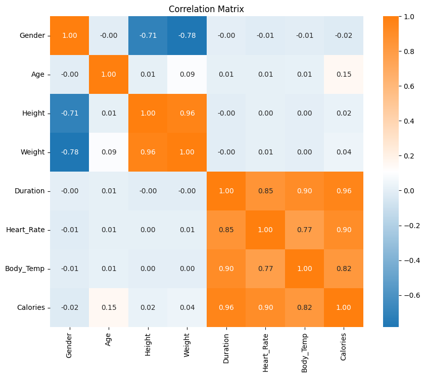

```python
# create a copy dataframe for the purposes of invetigating correlations
df_corr = df.copy()

# convert Gender 'MALE' to 'male' and 'FEMALE' to 'female'
df_corr['Gender'] = df_corr['Gender'].str.lower()

# extract numerical values from str
df_corr['Duration'] = df['Duration'].astype(str).str.extract(r'(\d+\.?\d*)')[0].astype(float)

# we need to convert categorical feature to binary in order to calculate correlation coefficients
# but we also need to keep a copy of the categorical for use in the distribution plots
df_distributions = df_corr.copy()

df_corr['Gender'] = df_corr['Gender'].map({'male': 0, 'female': 1})
plt.figure(figsize=(10, 8))

# custom colour to match histograms and Box plots
custom_cmap = mcolors.LinearSegmentedColormap.from_list("custom",
    ["#1f77b4", "white", "#ff7f0e"])

sns.heatmap(df_corr.corr(), annot=True,
            cmap=custom_cmap,
            fmt=".2f")

plt.title("Correlation Matrix")
plt.show()
```

### Feature Distributions

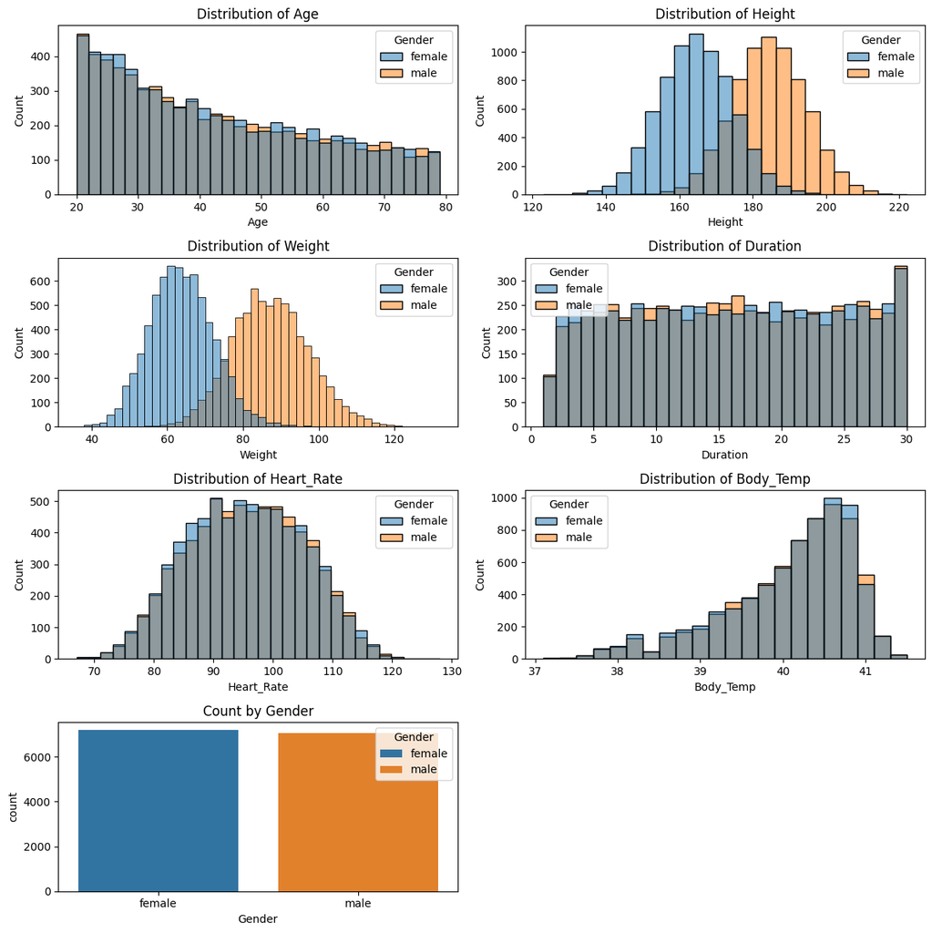

```python
# create a grid
fig, axes = plt.subplots(4, 2, figsize=(12, 12))

# Flatten axes array to simplify iteration over subplots
axes = axes.flatten()

# plot numerical features and set bin widths manually based on range of observations
cols_and_widths = [('Age', 2), ('Height', 4), ('Weight', 2), ('Duration', 1), ('Heart_Rate', 2),
    ('Body_Temp', 0.2)]

for i, col_and_width in enumerate(cols_and_widths):
    col, bin_width = col_and_width
    sns.histplot(
        data=df_distributions,
        x=col,
        hue='Gender', # superimpose separate plots for Gender
        alpha=0.5, # transparency for superimposed plots
        binwidth=bin_width,
        ax=axes[i],
        hue_order=['female', 'male'],
    )
    axes[i].set_title(f'Distribution of {col}')

# add categorical feature 'Gender'
sns.countplot(
    data=df_distributions,
    x='Gender',
    hue='Gender',
    ax=axes[6],
    order=['female', 'male'],
    hue_order=['female', 'male'],
)
axes[6].set_title('Count by Gender')
# remove unused last subplot
fig.delaxes(axes[-1])
plt.tight_layout()
plt.show()
```

### Imputation by Regression

Regression-based imputation is a technique that uses the relationships between features to estimate missing values. This approach is useful when features are correlated, as it allows us to make more informed predictions based on observed data. This method often yields more accurate imputations than simple strategies like using the mean or mode. For numerical features, we use linear regression to predict the missing values. For categorical features, we apply logistic regression.

### Imputation Strategy

The correlation matrix shows that `Height` and `Weight` are strongly correlated with `Gender`. In addition, the feature distributions indicate noticeable differences in the mean values of `Height` and `Weight` across `Gender` groups. When imputing missing values for these features, it is therefore sensible to include `Gender` as a predictor to account for this group-level effect. More generally, `Gender` may be included in imputation models for other features as well, since subtle group differences might exist even if not immediately apparent.

Lastly, `Gender` has the highest percentage of missing values and is highly correlated with `Height` and `Weight`. As `Height` and `Weight` are also highly correlated we will select only `Weight` as predictor. As this will be a binary categorical variable logistic regression imputation would be an appropriate method. We can then use `Height` as a fallback, and any remaining null values can be imputed probabilistically to preserve the original class distribution (which is approximately 50/50).  
In all these imputations we will also add an indicator column to the dataset to record which values have been imputed. It is always possible that there is predictive information in the missingness of values.

```python
def lowercase_gender(dataframe):
    dataframe['Gender'] = dataframe['Gender'].str.lower()
    return dataframe

def duration_extractor(dataframe):
    dataframe['Duration'] = dataframe['Duration'].str.extract(r'(\d+\.?\d*)')[0].astype(float)
    return dataframe

class SequentialRegressionImputer:
    def __init__(self, target_col, numerical_predictors, cat_predictor='Gender',
                 final_strategy='median', strictly_positive=False):
        """
        target_col: Column to impute
        numerical_predictors: Ordered list of numerical predictors to try
        cat_predictor: Categorical predictor column (default 'Gender')
        final_strategy: 'mean' or 'median' for final fallback
        strictly_positive: If we are only imputing values greater than 0
        """
        self.target_col = target_col
        self.numerical_predictors = numerical_predictors
        self.cat_predictor = cat_predictor
        self.final_strategy = final_strategy
        self.strictly_positive = strictly_positive

        # Standard OneHotEncoder configuration: drop='first' avoids multicollinearity,
        # handle_unknown='ignore' prevents errors from unseen categories at inference,
        # sparse_output=True saves memory for high-cardinality features.
        # For binary features, sparse_output=False is usually fine.
        self.encoder = OneHotEncoder(handle_unknown='ignore', drop='first', sparse_output=False)


    def fit(self, X, y=None):
        self.models_ = {}
        # Prepare categorical encoder
        self.encoder.fit(X[[self.cat_predictor]])

        # Train models for each predictor
        for num_pred in self.numerical_predictors:
            train_data = X[[num_pred, self.cat_predictor, self.target_col]].dropna()

            # need a minimum of 2 points
            if len(train_data) > 1:
                X_train = self._prepare_features(train_data, num_pred)
                y_train = train_data[self.target_col]

                model = LinearRegression()
                model.fit(X_train, y_train)
                self.models_[num_pred] = model

        return self

    def transform(self, X):
        check_is_fitted(self)
        X = X.copy()

        # Initialize missing mask
        missing_mask = X[self.target_col].isna()

        # Add missing indicator before imputation
        indicator_col = f"{self.target_col}_imputed"
        X[indicator_col] = missing_mask.astype(int)

        # Skip imputation if no missing values
        if not missing_mask.any():
            return X

        # Try predictors in order
        for num_pred in self.numerical_predictors:
            if not missing_mask.any():
                break

            if num_pred in self.models_:
                try:
                    pred_data = X.loc[missing_mask, [num_pred, self.cat_predictor]]
                    X_pred = self._prepare_features(pred_data, num_pred)
                    preds = self.models_[num_pred].predict(X_pred)

                    # if predictions must be strictly positive
                    if self.strictly_positive:
                        preds = np.clip(preds, a_min=1.0, a_max=None)

                    X.loc[missing_mask, self.target_col] = preds

                    missing_mask = X[self.target_col].isna()
                except:
                    continue

        # Final fallback
        if missing_mask.any():
            if self.final_strategy == 'mean':
                fill_value = X[self.target_col].mean()
            else:
                fill_value = X[self.target_col].median()
            X.loc[missing_mask, self.target_col] = fill_value

        return X

    def fit_transform(self, X, y=None):
        return self.fit(X).transform(X)

    def _prepare_features(self, df, numerical_predictor):
        """Prepare feature matrix with encoded categorical"""
        cat_encoded = self.encoder.transform(df[[self.cat_predictor]])
        # returns array of numerical_predictor and One Hot Encoded values
        return np.column_stack([
            df[numerical_predictor].values,
            cat_encoded
        ])


class ProbabilisticImputer:
    def __init__(self, feature, groupby=None, random_state=None):
        """
        feature: Column name to impute
        groupby: Column name(s) to group by (optional)
        random_state: For reproducibility
        """
        self.feature = feature
        self.groupby = groupby
        self.random_state = random_state

    def fit(self, X, y=None):
        # reproducible random number generator
        self.rng_ = np.random.RandomState(self.random_state)
        self.distributions_ = {}

        if self.groupby is None:
            # Global distribution
            non_null = X[self.feature].dropna()
            if len(non_null) > 0:
                self.distributions_['global'] = non_null.values
        else:
            # Grouped distributions
            groupby_cols = [self.groupby] if isinstance(self.groupby, str) else list(self.groupby)
            for name, group in X.groupby(groupby_cols)[self.feature]:
                non_null = group.dropna()
                if len(non_null) > 0:
                    self.distributions_[name] = non_null.values

        return self

    def transform(self, X):
        check_is_fitted(self)

        X = X.copy()
        missing_mask = X[self.feature].isna()

        X[f"{self.feature}_imputed"] = missing_mask.astype(int)

        if not missing_mask.any() or not self.distributions_:
            return X

        if self.groupby is None:
            # Global imputation
            samples = self.rng_.choice(
                self.distributions_['global'],
                size=missing_mask.sum(),
                replace=True
            )
            X.loc[missing_mask, self.feature] = samples
        else:
            # Grouped imputation
            groupby_cols = [self.groupby] if isinstance(self.groupby, str) else list(self.groupby)
            current_groups = X.groupby(groupby_cols).groups

            for group_name in current_groups:
                if group_name not in self.distributions_:
                    continue

                if isinstance(self.groupby, str):
                    group_mask = (X[self.groupby] == group_name)
                else:
                    group_mask = (X[groupby_cols] == group_name).all(axis=1)

                group_missing = missing_mask & group_mask
                if group_missing.any():
                    X.loc[group_missing, self.feature] = self.rng_.choice(
                        self.distributions_[group_name],
                        size=group_missing.sum(),
                        replace=True
                    )
        return X

    def fit_transform(self, X, y=None):
        return self.fit(X).transform(X)


class SequentialLogisticImputer(BaseEstimator, TransformerMixin):
    def __init__(self, target_col, predictors, random_state=None):
        self.target_col = target_col
        self.predictors = predictors  # List of predictors
        self.random_state = random_state

    def fit(self, X, y=None):
        # Save observed class probabilities for fallback
        self.models_ = {}
        observed = X[self.target_col].dropna()
        self.class_probs_ = observed.value_counts(normalize=True).to_dict()

        # Fit one model per predictor
        for predictor in self.predictors:
            mask = X[self.target_col].notna() & X[predictor].notna()
            X_train = X.loc[mask, predictor].values.reshape(-1, 1)
            y_train = X.loc[mask, self.target_col]
            model = LogisticRegression(random_state=self.random_state)
            model.fit(X_train, y_train)
            self.models_[predictor] = model

        return self

    def transform(self, X):
        check_is_fitted(self)
        X = X.copy()
        missing_mask = X[self.target_col].isna()

        # Indicator column
        X[f"{self.target_col}_imputed"] = missing_mask.astype(int)

        for predictor in self.predictors:
            mask = X[self.target_col].isna() & X[predictor].notna()
            if mask.any():
                X_pred = X.loc[mask, predictor].values.reshape(-1, 1)
                preds = self.models_[predictor].predict(X_pred)
                X.loc[mask, self.target_col] = preds

        # Final fallback: probabilistic imputation
        final_mask = X[self.target_col].isna()
        if final_mask.any() and self.class_probs_:
            values = np.random.choice(
                list(self.class_probs_.keys()),
                size=final_mask.sum(),
                p=list(self.class_probs_.values())
            )
            X.loc[final_mask, self.target_col] = values

        return X


preprocessor = Pipeline([
        ('gender_lowercase', FunctionTransformer(lowercase_gender)),
        ('duration_extraction', FunctionTransformer(duration_extractor)),
        ('body_temp_imputation', SequentialRegressionImputer('Body_Temp',
            ['Duration', 'Heart_Rate'])),
        ('height_imputation', SequentialRegressionImputer('Height',
            ['Weight'], final_strategy='mean')),
        ('weight_imputation', SequentialRegressionImputer('Weight',
            ['Height'], final_strategy='mean')),
        ('heart_rate_imputation', SequentialRegressionImputer('Heart_Rate',
            ['Duration', 'Body_Temp'], final_strategy='mean')),
        ('duration_imputation', SequentialRegressionImputer('Duration',
            ['Body_Temp','Heart_Rate'], final_strategy='mean', strictly_positive=True)),
        ('age_imputation', ProbabilisticImputer('Age')),
        ('gender_imputation', SequentialLogisticImputer('Gender', ['Weight', 'Height'])),
    ])
```

```python
df_cleaned = preprocessor.fit_transform(df)
```

### Post-processing checks

Having processed the data we will perform some checks to make sure that the processing has performed as expected. In particular we will check that:

- Target column `Calories` has not been altered in any way

```python
display(Markdown(f"<span style='color: green;'>&emsp;&emsp;{tick}</span>"
    f" `Calories` is {'unchanged' if df['Calories'].equals(df_cleaned['Calories']) else 'changed'} \
    by cleaning process"))
```

✓ `Calories` is unchanged by cleaning process

- `Gender` has no misformed values ie all values are either 'male' or 'female'

```python
display(Markdown(f"<span style='color: green;'>&emsp;&emsp;{tick}</span>"
    f" `Gender` values in the cleaned data: {', '.join(df_cleaned['Gender'].unique())}"))
```

✓ `Gender` values in the cleaned data: male, female

- `Duration` is now a `float` data type and all values are numerical

```python
display(Markdown(f"<span style='color: green;'>&emsp;&emsp;{tick}</span>"
    f" `Duration` data type: {df_cleaned['Duration'].dtype}"))
```

✓ `Duration` data type: float64

- The range of values for each numerical feature is approximately the same for pre- and post-processed data

```python
feature_columns = ['Age', 'Height', 'Weight', 'Duration', 'Body_Temp', 'Heart_Rate']
for col in feature_columns:
    assert abs(df_cleaned[col].max()- df[col].max()) / df_cleaned[col].max() < 0.02
    assert abs(df_cleaned[col].min()- df[col].min()) / df_cleaned[col].min() < 0.02
display(Markdown(f"<span style='color: green;'>&emsp;&emsp;{tick}</span>"
    " The ranges of values in the cleaned dataset are within 2% of the original data"))
```

✓ The ranges of values in the cleaned dataset are within 2% of the original data

- There are no remaining null values in the data

```python
display(Markdown(f"<span style='color: green;'>&emsp;&emsp;{tick}</span>"
    f" Number of null values: {df_cleaned.isna().sum().sum()}"))
```

✓ Number of null values: 0

- The imputed indicators in the cleaned data correspond with the missing values in the original data

```python
for col in feature_columns:
    original_missing = df[col].isna()
    imputed_flags = df_cleaned[f"{col}_imputed"] == 1
    assert (original_missing == imputed_flags).all()
display(Markdown(f"<span style='color: green;'>&emsp;&emsp;{tick}</span>"
    " Imputed indicators in cleaned data correspond with missing values in original data"))
```

✓ Imputed indicators in cleaned data correspond with missing values in original data

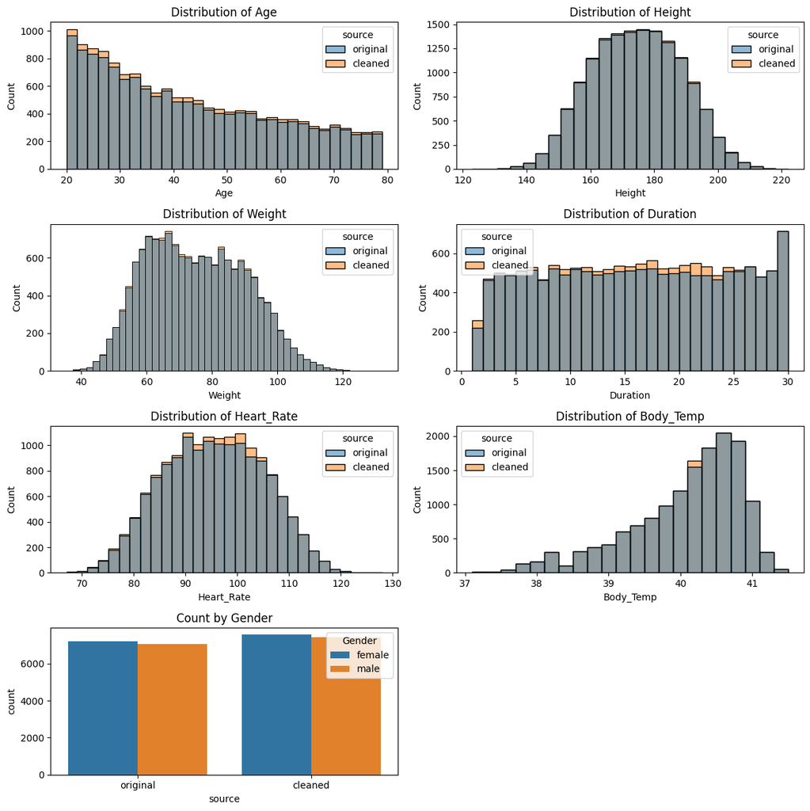

```python
# Add source column
df_copy = df.copy()
df_copy['source'] = 'original'

df_cleaned_copy = df_cleaned.copy()
df_cleaned_copy['source'] = 'cleaned'

# Combine both
df_combined = pd.concat([df_copy, df_cleaned_copy], ignore_index=True)

# create a grid
fig, axes = plt.subplots(4, 2, figsize=(12, 12))
# Flatten axes array to simplify iteration over subplots
axes = axes.flatten()

# plot numerical features and set bin widths manually based on range of observations
cols_and_widths = [('Age', 2), ('Height', 4), ('Weight', 2), ('Duration', 1), ('Heart_Rate', 2),
    ('Body_Temp', 0.2)]

for i, col_and_width in enumerate(cols_and_widths):
    col, bin_width = col_and_width
    sns.histplot(
        data=df_combined,
        x=col,
        hue='source', # superimpose separate plots for Gender
        alpha=0.5, # transparency for superimposed plots
        binwidth=bin_width,
        ax=axes[i],
        hue_order=['original', 'cleaned'],
    )
    axes[i].set_title(f'Distribution of {col}')

# add categorical feature 'Gender'
sns.countplot(
    data=df_combined,
    x='source',
    hue='Gender',
    ax=axes[6],

)
axes[6].set_title('Count by Gender')
fig.delaxes(axes[-1])
plt.tight_layout()
plt.show()
```

### Conclusion

The data cleaning process has successfully addressed key quality issues, including missing values, inconsistent data types and malformed entries. Imputation strategies preserved the underlying distributions and relationships between features. Post-cleaning checks confirm that the dataset is internally consistent and suitable for downstream tasks such as feature engineering and modeling